# DC Exercises: Chapters 5 & 6 Solutions

Written by Emily Strong

6/5/2020

# Exercise 5.1

```r
library(mosaicData)
library(DataComputing)
barGraphHelper(CPS85)
```

Running the line `help(CPS85)` shows under the “Format” section that the variable with levels NW and W is `race`. The plot can be recreated with the following settings:

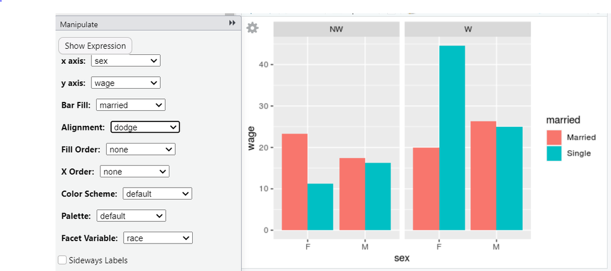

Clicking on the “Show Expression” button on the menu, its output in the console shows that the following code may also be used to recreate the graph:

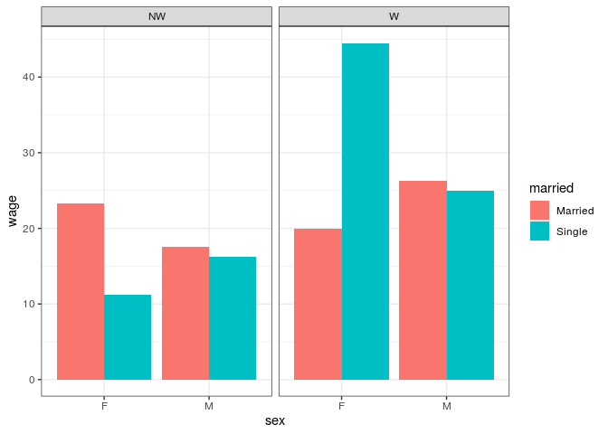

```r
library(ggplot2)
library(mosaicData)
ggplot(data=CPS85,aes(x=sex,y=wage ,fill=married)) +
  geom_bar(stat='identity',position='dodge', width=.9) +
  facet_wrap(~race,ncol=3) +
  theme_bw()
```

(Though we have not explicitly been introduced to ggplot yet, so do not worry about this or about getting the white background in the graph.)

# Exercise 5.2

```r
distributionGraphHelper(NCHS, format = "density")
```

The plot can be recreated with the following settings:

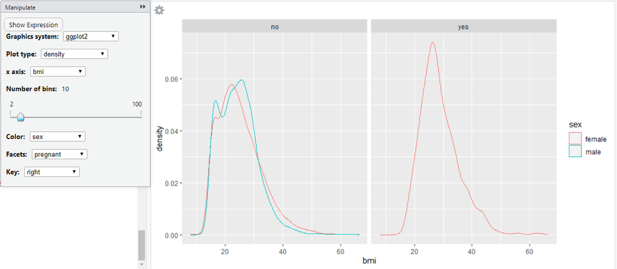

or by using the following code output by “Show Expression”:

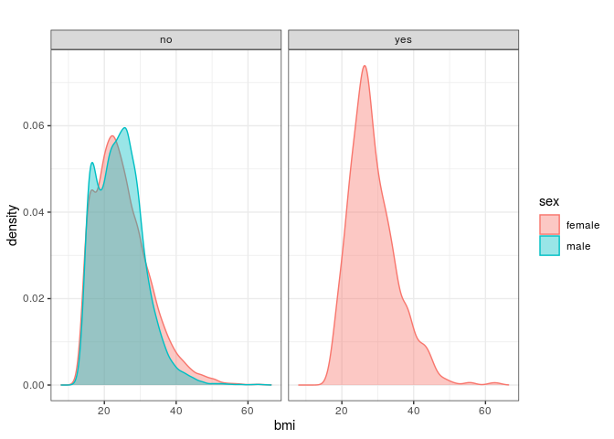

```r
library(DataComputing)
ggplot(data=NCHS, aes(x=bmi)) +
  geom_density(adjust = 1, aes(colour = sex, fill=sex), alpha=0.4) +
  facet_wrap(~pregnant, ncol = 4) +
  labs(title = "") +
  theme(legend.position = "right") +
  theme_bw()
```

# Exercise 5.3

```r
scatterGraphHelper(CPS85)
```

The plot can be recreated with the following settings:

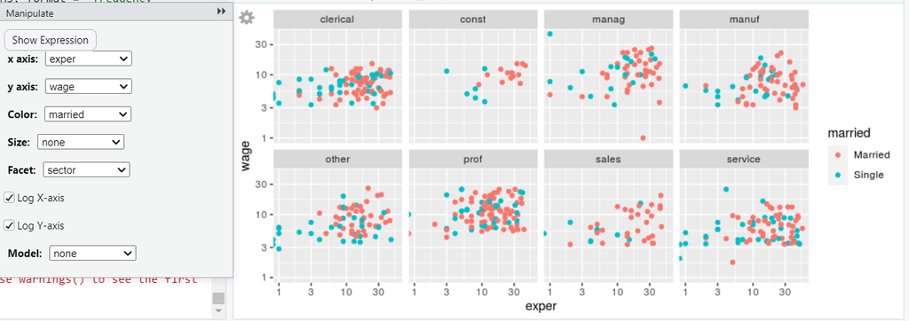

or by using the following code output by “Show Expression”:

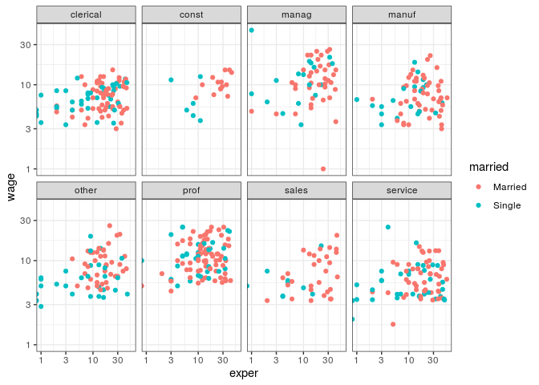

```r
ggplot(data=CPS85,aes(x=exper,y=wage)) +
  geom_point()+
  aes(colour=married) +
  scale_x_log10() +
  scale_y_log10() +
  facet_wrap(~sector,ncol=4) +
  theme_bw()
```

# Exercise 6.1

## Part (a)

The facet labels are “1433B”, “1433E”, “1433G” and “1433Z”. Each substance identifies with its own facet.

## Part (b)

No, the frames are not the same for all of the facets. The frames are set by a growth condition (x-axis), and the amount of the particular substance substance under each of those conditions (y-axis). The frame determines what the $(x,y)$ position of a glyph implies about an observation. For an (x,y) value of (adhesion growth , 2.00%) in the top left facet, the bar will be in the bottom right corner of the frame; however, for an (x,y) value of (adhesion growth, 2.00%) in the bottom left facet, the bar will be in the middle of the right side of the frame. So the (x,y) value of (adhesion growth, 2.00%) has a different position in two different facets, implying that the frames are not the same.

## Part (c)

The three different glyphs are:

1. Vertical bar: A black line. The size of each bar is determined by the amount of the substance under a certain condition. Location of each bar in the frame is determined by both the condition and the amount of the substance under that condition.
2. Line: A red line. Location of the line in the frame is determined by both the condition and the amount of the substance under that condition.
3. Point: A black star/asterisk. No guide for, or information about, is given for these points, so we are not able to conclude anything about its location attribute.

Each glyph corresponds to a single case, which is a substance under a particular condition.

# Exercise 6.2

## Part (a)

Recall that guides help someone viewing a graph to determine what the aesthetic properties (i.e. graphical attributes) of a glyph imply about the value of a particular variable for an observation. Common guides are x- and y-axis tick marks, and color keys. This graph has the following guides:

- x-axis: maps the `gene` variable to location of points (which are glyphs) in the frame
- y-axis: maps the `concentration` variable to location of points in the frame
- box in top right of frame: maps the `flux` variable to fill of points in the frame
- box in bottom of frame: maps the `molecule` variable to color of points in the frame
- brackets with labels in top of frame: map the `target` variable to location of points in the frame

## Part (b)

The graphical attributes of the glyphs/dots in the frame are:

- color: determined by `molecule`
- fill: determined by `flux`
- location: determined by `concentration`, `target`, `gene`

## Part (c)

The `concentration` and `gene`variables set the frame; these variables (along with `target`, as we see in part (d)) determine what the $(x,y)$ position of a glyph implies about the concentration of a specific gene.

## Part (d)

The scaling of the horizontal variable is set by a combination of the variables `gene` and `target`. We can see that the genes along the x-axis have been arranged based on their values of `target`, which is shown by the guide at the top of the frame.

# Exercise 6.3

## Part (a)

1. Vertical bar with dot: A black line. The label is determined by `protein`, and the color of the label is determined by `polarity`. The size of each bar is determined by both `low` and `high`. Location of each bar in the frame is seems to be determined by `center`. Each glyph gives information about the value of several variables for a specific protein.
2. Point: A double black star/asterisk. Location of a point in the frame is determined by `signif` The glyph represents a particular value of `signif` for each protein.

*Note*: for the variables that determine location of the glyph in the frame, I found it helpful to ask myself: If I move a glyph to somewhere else in the frame, what variables am I changing if I do so? For example, if I move the bar glyph labeled “1433G” vertically in the frame, then I am *only* changing the its value of the `center` variable; if I move it horizontally, I am not changing the value of any variable. As another example, if I move the star glyph above the bar glyph labeled “1433G” vertically in the frame, I am not changing the value of any variable; however, if I move it horizontally, then I am changing this protein’s value of `signif`.

## Part (b)

The `center`and `signif` variables define the frame; the value of `center` determines the position of the bar glyph in the frame, and the value of `signif` determines the position of the star glyphs in the frame, respectively. Note that “log2 ratio low vs high cell density” does not define the frame, because it is not a variable; it is just the y-axis title, and measures the values of `center`, `low` and `high` for each observation.

## Part (c)

Yes, color is an attribute of the bar glyph. The label color of the glyph is determined by the apico-basal cell polarity property of a protein, described by the `polarity` variable.

## Part (d)

The guides for this graph are:

- y-axis: maps the `center` variable to location of bars in the frame.
- the blue text “apico-basal cell polarity proteins” maps the variable `polarity` to the label color of the bar glyphs.

# Exercise 6.4

## Part (a)

The frame is a time-schedule. The time determines the position of the glyphs in the frame.

## Part (b)

Each case is a different bus in a mass transit option. There is a line for each one of the buses. For each line glyph, the graphical attributes are

- color: maps to type of transportation
- location: (both horizontal and vertical) maps to time
- size/length: maps to length of time, or arrival and departure time

For each picture glyph, the graphical attributes are:

- label: maps to type of transportation
- location: maps to time

## Part (c)

For each line glyph, the length of the bus ride and the type of transportation is encoded in the size and color of the glyph. The time of arrival of the bus is encoded in the position of the glyph. For each picture glyph, the type of transportation is enoded in the shape of the glyph. The time of arrival is encoded in the position of the glyph.

## Part (d)

The guides are:

- times along the left of the bus routes: give meaning to the vertical position of glyphs
- times along the right of the bus routes: give meaning to the vertical position of glyphs
- times along the top of the schedule: give meaning to the horizontal position of glyphs

The labels next to the picture glyphs could also be considered guides, giving meaning to the shape of the picture glyphs and the color of the lines

# Exercise 6.5

The variables defining the frame are

2. State and Polling Organization.

We can see that where a glyph is placed in the frame, and what its position means, depend on its value of state and polling organization.

# Exercise 6.6

In this figure, the glyph and its graphical attributes are

3. Glyph: Rectangle. Graphical attribute: color.

Each observation is a unique combination of state and polling organization, and each rectangle represents one of these combinations. The color of each rectangle represents the qualitative polling results of a particular organization in a particular state, while the text in each rectangle gives more information about the results for each case.

# Exercise 6.7

In this figure,

4. NYT poll probability for the Democratic candidate

sets the order of the categorical variable in the scale for the vertical variable. Notice that the states are arranged on the vertical axis in order from highest percentage Democrat $\rightarrow$ highest percentage Reupblican, based on the results from the NYT poll.

# Exercise 6.8

In this figure,

1. Vertical scale: Name of state
2. Color: color band

are guides for the indicated graphical attributes. The names of states (kinf of like “tick marks” on the y-axis), tell us what the vertical position of a glyph means. The color band tells us the what the color of a glyph means.

# Exercise 6.9

```r
Small <-
  NCHS %>%
  sample_n(size=5000)
```

```r
scatterGraphHelper(Small)
```

This plot can be recreated with the following settings:

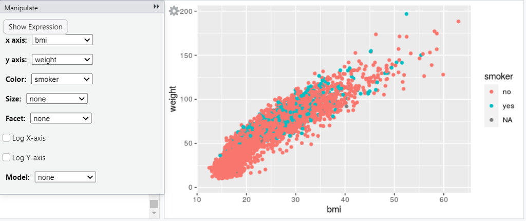

or by using the following code output by “Show Expression”:

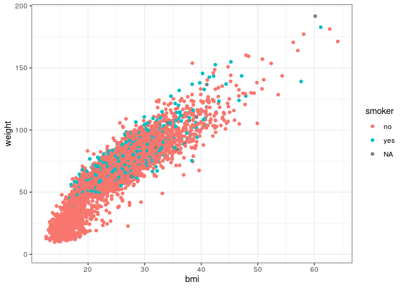

```r
ggplot(data=Small,aes(x=bmi,y=weight)) +
  geom_point() +
  aes(colour=smoker) +
  theme_bw()
```

In this graph,

- `bmi` (horizontal) and `weight` map to the location attribute
- `smoker` maps to the color attribute